# R Notebook

Data obtained from tidytuesday - who got it from kaggle - who got it from the NRF (National Retail Federation)

Roses are red, violets are blue. ❤  
Data has patterns, and models find clues.  
°˖✿˚⋆ChatGPT⋆˚✿˖°

💕 Exploratory Data Analysis 💕

# Libraries ❤

```r
library(tidytuesdayR)
library(tidyverse)
library(ggcorrplot)
```

# Data ❤

```r
tuesdata <- tidytuesdayR::tt_load('2024-02-13')
```

```
---- Compiling #TidyTuesday Information for 2024-02-13 ------- There are 3 files available ---
── Downloading files ────────────────────────────────────────────────────────────────
  1 of 3: "historical_spending.csv"  2 of 3: "gifts_age.csv"  3 of 3: "gifts_gender.csv"
```

```r
historical_spending <- tuesdata$historical_spending
gifts_age <- tuesdata$gifts_age
gifts_gender <- tuesdata$gifts_gender
```

# Valentines Goal ❤

Today we are going to take a brief pause from our regular schedule to focus on just some data exploration. Many of you have already seen this before but you will need it for your projects and so we will use this holiday to have fun either catching up on or learning how to make some nice data visualizations in R.

# Checking the Data ❤

As we’ve said before, we need to get a good look at our data and check for a few things:

- Are there missing values?
- Are there outliers we need to be aware of?
- Are there unusual names for our variables?
- Do we know the units we are dealing in?
- Are the vectors type representative of the data they hold? (numerical, character, etc)
- Is there anything of note we should consider?

```r
# Lets just check the first few rows of our data
head(gifts_age, 10)
```

| Age | SpendingCelebrating | Candy | Flowers | Jewelry | GreetingCards | EveningOut | Clothing | GiftCards |
| --- | --- | --- | --- | --- | --- | --- | --- | --- |
| 18-24 | 51 | 70 | 50 | 33 | 33 | 41 | 33 | 23 |
| 25-34 | 40 | 62 | 44 | 34 | 33 | 37 | 27 | 19 |
| 35-44 | 31 | 58 | 41 | 29 | 42 | 30 | 26 | 22 |
| 45-54 | 19 | 60 | 37 | 20 | 42 | 31 | 20 | 23 |
| 55-64 | 18 | 50 | 32 | 13 | 43 | 29 | 19 | 20 |
| 65+ | 13 | 42 | 25 | 8 | 44 | 24 | 12 | 20 |

```r
head(gifts_gender, 10)
```

| Gender | SpendingCelebrating | Candy | Flowers | Jewelry | GreetingCards | EveningOut | Clothing | GiftCards |
| --- | --- | --- | --- | --- | --- | --- | --- | --- |
| Men | 27 | 52 | 56 | 30 | 37 | 33 | 20 | 18 |
| Women | 27 | 59 | 19 | 14 | 43 | 29 | 24 | 24 |

```r
head(historical_spending, 10)
```

| Year | PercentCelebrating | PerPerson | Candy | Flowers | Jewelry | GreetingCards | EveningOut | Clothing | GiftCards |
| --- | --- | --- | --- | --- | --- | --- | --- | --- | --- |
| 2010 | 60 | 103.00 | 8.60 | 12.33 | 21.52 | 5.91 | 23.76 | 10.93 | 8.42 |
| 2011 | 58 | 116.21 | 10.75 | 12.62 | 26.18 | 8.09 | 24.86 | 12.00 | 11.21 |
| 2012 | 59 | 126.03 | 10.85 | 13.49 | 29.60 | 6.93 | 25.66 | 10.42 | 8.43 |
| 2013 | 60 | 130.97 | 11.64 | 13.48 | 30.94 | 8.32 | 27.93 | 11.46 | 10.23 |
| 2014 | 54 | 133.91 | 10.80 | 15.00 | 30.58 | 7.97 | 27.48 | 13.37 | 9.00 |
| 2015 | 55 | 142.31 | 12.70 | 15.72 | 36.30 | 7.87 | 27.27 | 14.72 | 11.05 |
| 2016 | 55 | 146.84 | 13.11 | 14.78 | 33.11 | 8.52 | 33.46 | 15.05 | 12.52 |
| 2017 | 54 | 136.57 | 12.68 | 14.63 | 32.32 | 7.36 | 28.46 | 13.91 | 10.23 |
| 2018 | 55 | 143.56 | 13.12 | 14.75 | 34.10 | 6.55 | 26.96 | 14.04 | 11.04 |
| 2019 | 51 | 161.96 | 14.12 | 15.07 | 30.34 | 7.31 | 27.72 | 16.08 | 10.31 |

```r
NA
```

> NOTES:

# Summary Statistics ❤

```r
# Lets look at a summary of the data
summary(gifts_age)
```

```
     Age            SpendingCelebrating     Candy         Flowers
 Length:6           Min.   :13.00       Min.   :42.0   Min.   :25.00
 Class :character   1st Qu.:18.25       1st Qu.:52.0   1st Qu.:33.25
 Mode  :character   Median :25.00       Median :59.0   Median :39.00
                    Mean   :28.67       Mean   :57.0   Mean   :38.17
                    3rd Qu.:37.75       3rd Qu.:61.5   3rd Qu.:43.25
                    Max.   :51.00       Max.   :70.0   Max.   :50.00
    Jewelry      GreetingCards     EveningOut       Clothing       GiftCards
 Min.   : 8.00   Min.   :33.00   Min.   :24.00   Min.   :12.00   Min.   :19.00
 1st Qu.:14.75   1st Qu.:35.25   1st Qu.:29.25   1st Qu.:19.25   1st Qu.:20.00
 Median :24.50   Median :42.00   Median :30.50   Median :23.00   Median :21.00
 Mean   :22.83   Mean   :39.50   Mean   :32.00   Mean   :22.83   Mean   :21.17
 3rd Qu.:32.00   3rd Qu.:42.75   3rd Qu.:35.50   3rd Qu.:26.75   3rd Qu.:22.75
 Max.   :34.00   Max.   :44.00   Max.   :41.00   Max.   :33.00   Max.   :23.00
```

```r
summary(gifts_gender)
```

```
    Gender          SpendingCelebrating     Candy          Flowers         Jewelry
 Length:2           Min.   :27          Min.   :52.00   Min.   :19.00   Min.   :14
 Class :character   1st Qu.:27          1st Qu.:53.75   1st Qu.:28.25   1st Qu.:18
 Mode  :character   Median :27          Median :55.50   Median :37.50   Median :22
                    Mean   :27          Mean   :55.50   Mean   :37.50   Mean   :22
                    3rd Qu.:27          3rd Qu.:57.25   3rd Qu.:46.75   3rd Qu.:26
                    Max.   :27          Max.   :59.00   Max.   :56.00   Max.   :30
 GreetingCards    EveningOut    Clothing    GiftCards
 Min.   :37.0   Min.   :29   Min.   :20   Min.   :18.0
 1st Qu.:38.5   1st Qu.:30   1st Qu.:21   1st Qu.:19.5
 Median :40.0   Median :31   Median :22   Median :21.0
 Mean   :40.0   Mean   :31   Mean   :22   Mean   :21.0
 3rd Qu.:41.5   3rd Qu.:32   3rd Qu.:23   3rd Qu.:22.5
 Max.   :43.0   Max.   :33   Max.   :24   Max.   :24.0
```

```r
summary(historical_spending)
```

```
      Year      PercentCelebrating   PerPerson         Candy          Flowers
 Min.   :2010   Min.   :51.00      Min.   :103.0   Min.   : 8.60   Min.   :12.33
 1st Qu.:2013   1st Qu.:54.00      1st Qu.:131.0   1st Qu.:10.85   1st Qu.:13.49
 Median :2016   Median :55.00      Median :142.3   Median :12.70   Median :14.78
 Mean   :2016   Mean   :55.46      Mean   :144.4   Mean   :12.84   Mean   :14.65
 3rd Qu.:2019   3rd Qu.:58.00      3rd Qu.:162.0   3rd Qu.:14.12   3rd Qu.:15.42
 Max.   :2022   Max.   :60.00      Max.   :196.3   Max.   :17.30   Max.   :16.71
    Jewelry      GreetingCards     EveningOut       Clothing       GiftCards
 Min.   :21.52   Min.   :5.910   Min.   :21.39   Min.   :10.42   Min.   : 8.42
 1st Qu.:30.34   1st Qu.:7.310   1st Qu.:25.66   1st Qu.:12.00   1st Qu.:10.23
 Median :30.94   Median :7.870   Median :27.48   Median :14.04   Median :11.04
 Mean   :32.55   Mean   :7.676   Mean   :27.47   Mean   :14.94   Mean   :11.50
 3rd Qu.:34.10   3rd Qu.:8.320   3rd Qu.:28.46   3rd Qu.:16.08   3rd Qu.:12.52
 Max.   :45.75   Max.   :9.010   Max.   :33.46   Max.   :21.46   Max.   :17.22
```

```r
# Now try to take a glimpse
glimpse(gifts_age)
```

```
Rows: 6
Columns: 9
$ Age                 <chr> "18-24", "25-34", "35-44", "45-54", "55-64", "65+"
$ SpendingCelebrating <dbl> 51, 40, 31, 19, 18, 13
$ Candy               <dbl> 70, 62, 58, 60, 50, 42
$ Flowers             <dbl> 50, 44, 41, 37, 32, 25
$ Jewelry             <dbl> 33, 34, 29, 20, 13, 8
$ GreetingCards       <dbl> 33, 33, 42, 42, 43, 44
$ EveningOut          <dbl> 41, 37, 30, 31, 29, 24
$ Clothing            <dbl> 33, 27, 26, 20, 19, 12
$ GiftCards           <dbl> 23, 19, 22, 23, 20, 20
```

```r
glimpse(gifts_gender)
```

```
Rows: 2
Columns: 9
$ Gender              <chr> "Men", "Women"
$ SpendingCelebrating <dbl> 27, 27
$ Candy               <dbl> 52, 59
$ Flowers             <dbl> 56, 19
$ Jewelry             <dbl> 30, 14
$ GreetingCards       <dbl> 37, 43
$ EveningOut          <dbl> 33, 29
$ Clothing            <dbl> 20, 24
$ GiftCards           <dbl> 18, 24
```

```r
glimpse(historical_spending)
```

```
Rows: 13
Columns: 10
$ Year               <dbl> 2010, 2011, 2012, 2013, 2014, 2015, 2016, 2017, 2018, 20…
$ PercentCelebrating <dbl> 60, 58, 59, 60, 54, 55, 55, 54, 55, 51, 55, 52, 53
$ PerPerson          <dbl> 103.00, 116.21, 126.03, 130.97, 133.91, 142.31, 146.84, …
$ Candy              <dbl> 8.60, 10.75, 10.85, 11.64, 10.80, 12.70, 13.11, 12.68, 1…
$ Flowers            <dbl> 12.33, 12.62, 13.49, 13.48, 15.00, 15.72, 14.78, 14.63, …
$ Jewelry            <dbl> 21.52, 26.18, 29.60, 30.94, 30.58, 36.30, 33.11, 32.32, …
$ GreetingCards      <dbl> 5.91, 8.09, 6.93, 8.32, 7.97, 7.87, 8.52, 7.36, 6.55, 7.…
$ EveningOut         <dbl> 23.76, 24.86, 25.66, 27.93, 27.48, 27.27, 33.46, 28.46, …
$ Clothing           <dbl> 10.93, 12.00, 10.42, 11.46, 13.37, 14.72, 15.05, 13.91, …
$ GiftCards          <dbl> 8.42, 11.21, 8.43, 10.23, 9.00, 11.05, 12.52, 10.23, 11.…
```

> NOTES:

# Data Wrangling ❤

```r
# lets restructure our data so we can make visuals! First we will look at column names

colnames(gifts_age)
```

```
[1] "Age"                 "SpendingCelebrating" "Candy"
[4] "Flowers"             "Jewelry"             "GreetingCards"
[7] "EveningOut"          "Clothing"            "GiftCards"
```

```r
colnames(gifts_gender)
```

```
[1] "Gender"              "SpendingCelebrating" "Candy"
[4] "Flowers"             "Jewelry"             "GreetingCards"
[7] "EveningOut"          "Clothing"            "GiftCards"
```

```r
colnames(historical_spending)
```

```
 [1] "Year"               "PercentCelebrating" "PerPerson"
 [4] "Candy"              "Flowers"            "Jewelry"
 [7] "GreetingCards"      "EveningOut"         "Clothing"
[10] "GiftCards"
```

Now we are going to pivot our data long-wise so that we can plot it! Keep track of numerical and non-numerical! Why do you think we need to keep this in mind when we pivot? What is the new shape of our data?

```r
Valen_long <- gifts_age %>%
  pivot_longer(cols = -Age,
               names_to = "Feature",
               values_to = "Value")

Valen_long
```

| Age | Feature | Value |
| --- | --- | --- |
| 18-24 | SpendingCelebrating | 51 |
| 18-24 | Candy | 70 |
| 18-24 | Flowers | 50 |
| 18-24 | Jewelry | 33 |
| 18-24 | GreetingCards | 33 |
| 18-24 | EveningOut | 41 |
| 18-24 | Clothing | 33 |
| 18-24 | GiftCards | 23 |
| 25-34 | SpendingCelebrating | 40 |
| 25-34 | Candy | 62 |

[output cut: 38 more lines]

```r
Valen_long_Gender <- gifts_gender %>%
    pivot_longer(cols = -Gender,
               names_to = "Feature",
               values_to = "Value")

Valen_long_Gender
```

| Gender | Feature | Value |
| --- | --- | --- |
| Men | SpendingCelebrating | 27 |
| Men | Candy | 52 |
| Men | Flowers | 56 |
| Men | Jewelry | 30 |
| Men | GreetingCards | 37 |
| Men | EveningOut | 33 |
| Men | Clothing | 20 |
| Men | GiftCards | 18 |
| Women | SpendingCelebrating | 27 |
| Women | Candy | 59 |

[output cut: 6 more lines]

```r
NA
```

```r
glimpse(historical_spending)
```

```
Rows: 13
Columns: 10
$ Year               <dbl> 2010, 2011, 2012, 2013, 2014, 2015, 2016, 2017, 2018, 20…
$ PercentCelebrating <dbl> 60, 58, 59, 60, 54, 55, 55, 54, 55, 51, 55, 52, 53
$ PerPerson          <dbl> 103.00, 116.21, 126.03, 130.97, 133.91, 142.31, 146.84, …
$ Candy              <dbl> 8.60, 10.75, 10.85, 11.64, 10.80, 12.70, 13.11, 12.68, 1…
$ Flowers            <dbl> 12.33, 12.62, 13.49, 13.48, 15.00, 15.72, 14.78, 14.63, …
$ Jewelry            <dbl> 21.52, 26.18, 29.60, 30.94, 30.58, 36.30, 33.11, 32.32, …
$ GreetingCards      <dbl> 5.91, 8.09, 6.93, 8.32, 7.97, 7.87, 8.52, 7.36, 6.55, 7.…
$ EveningOut         <dbl> 23.76, 24.86, 25.66, 27.93, 27.48, 27.27, 33.46, 28.46, …
$ Clothing           <dbl> 10.93, 12.00, 10.42, 11.46, 13.37, 14.72, 15.05, 13.91, …
$ GiftCards          <dbl> 8.42, 11.21, 8.43, 10.23, 9.00, 11.05, 12.52, 10.23, 11.…
```

```r
Valen_long_History <- historical_spending %>%
    pivot_longer(cols = -c(Year, PercentCelebrating, PerPerson),
               names_to = "Feature",
               values_to = "Value")

Valen_long_History
```

| Year | PercentCelebrating | PerPerson | Feature | Value |
| --- | --- | --- | --- | --- |
| 2010 | 60 | 103.00 | Candy | 8.60 |
| 2010 | 60 | 103.00 | Flowers | 12.33 |
| 2010 | 60 | 103.00 | Jewelry | 21.52 |
| 2010 | 60 | 103.00 | GreetingCards | 5.91 |
| 2010 | 60 | 103.00 | EveningOut | 23.76 |
| 2010 | 60 | 103.00 | Clothing | 10.93 |
| 2010 | 60 | 103.00 | GiftCards | 8.42 |
| 2011 | 58 | 116.21 | Candy | 10.75 |
| 2011 | 58 | 116.21 | Flowers | 12.62 |
| 2011 | 58 | 116.21 | Jewelry | 26.18 |

[output cut: 81 more lines]

```r
NA
```

> NOTES:

# Data Visuals ❤

Now we can finally start getting some visuals for our data! Before we actually make our visuals there are a few things you want to keep in mind:

- What is the goal of the visual?
- Are there any relationships you would like to see?
- What variables stand out to you as possibly being the most integral?

Let’s Look! Let’s See!

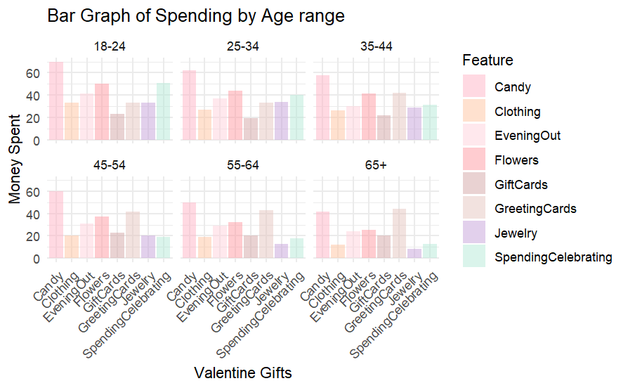

```r
ggplot(Valen_long, aes(x = Feature, y = Value ,fill = Feature)) +
  geom_col(alpha = 0.5, position = "dodge") +
  facet_wrap(~Age) +
  theme_minimal() +
  labs(title = "Bar Graph of Spending by Age range",
       x = "Valentine Gifts",
       y = "Money Spent") +
  scale_fill_manual(values = c("#FFB3C6","#FFC3A0", "#FFD1DC", "#FF9AA2", "#D4A5A5", "#E6C6C0" ,"#C6A2D9","#B5EAD7") )+
  theme(axis.text.x = element_text(angle = 45, hjust = 1))
```

> NOTES:

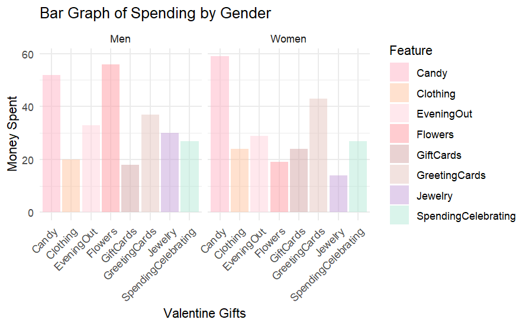

```r
ggplot(Valen_long_Gender, aes(x = Feature, y = Value ,fill = Feature)) +
  geom_col(alpha = 0.5, position = "dodge") +
  facet_wrap(~Gender) +
  theme_minimal() +
  labs(title = "Bar Graph of Spending by Gender",
       x = "Valentine Gifts",
       y = "Money Spent") +
  scale_fill_manual(values = c("#FFB3C6","#FFC3A0", "#FFD1DC", "#FF9AA2", "#D4A5A5", "#E6C6C0" ,"#C6A2D9","#B5EAD7") )+
  theme(axis.text.x = element_text(angle = 45, hjust = 1))
```

> NOTES:

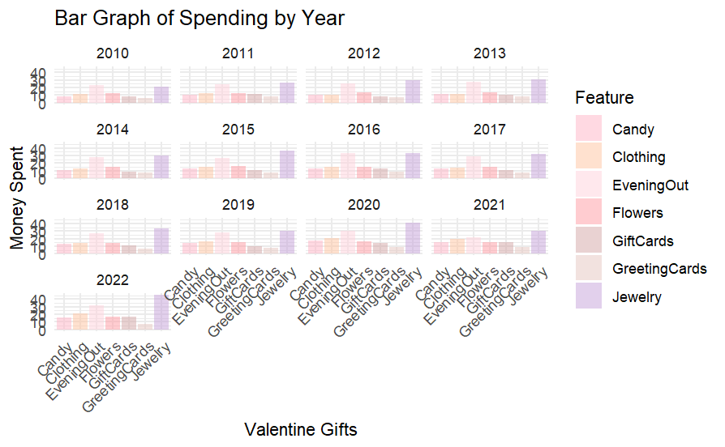

```r
ggplot(Valen_long_History, aes(x = Feature, y = Value ,fill = Feature)) +
  geom_col(alpha = 0.5, position = "dodge") +
  facet_wrap(~Year) +
  theme_minimal() +
  labs(title = "Bar Graph of Spending by Year",
       x = "Valentine Gifts",
       y = "Money Spent") +
  scale_fill_manual(values = c("#FFB3C6","#FFC3A0", "#FFD1DC", "#FF9AA2", "#D4A5A5", "#E6C6C0" ,"#C6A2D9","#B5EAD7") )+
  theme(axis.text.x = element_text(angle = 45, hjust = 1))
```

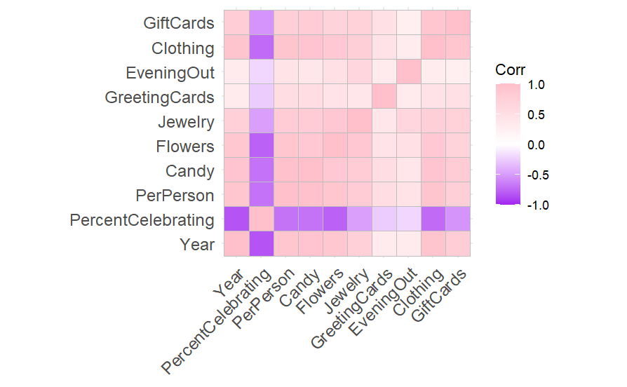

```r
Cor <- cor(historical_spending)
ggcorrplot(Cor, colors = c("purple","white", "pink"))
```

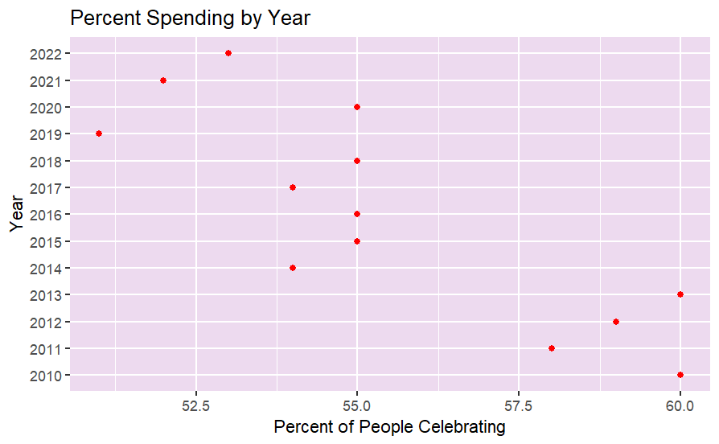

```r
ggplot(historical_spending) +
  geom_point( mapping = aes(x = PercentCelebrating, y = as.factor(Year)), color = "red") +
  ggtitle("Percent Spending by Year") +
  xlab("Percent of People Celebrating") +
  ylab("Year") +
  theme(panel.background = element_rect(fill = "#eddaef"))
```

> NOTES:

> Finally: Please submitt the html for this lab to canvas for credit by the end of the day February 14, 2025 ❤